# TFM - Scenario 2

Antonio Milán Otero

16 de June 2019

# 1 Study of the Transcriptional Function of Cyclin D1 in Leukemia - Scenario 2

## 1.1 Load the datasets

For this study we will make use of the following datasets available in the Gene Expression Omnibus (GEO) repository:

- GSE21452
- GSE25848

The first step will be the loading of the datasets. For that purpose we will use the bioconductor package GEOquery. This package will allow us to load the dataset directly from the filesystem or to download it directly using the same command. In my case, I have already downloade the dataset, and I will use it from the filesystem.

```r
gse_21452 <- getGEO(filename="data/GSE21452_series_matrix.txt.gz")
```

```
## File stored at:
```

```
## /tmp/RtmputHVY7/GPL570.soft
```

```r
# In case you don't have it donwloaded, this dataset can be obtained with the command:
# gse21452 <- getGEO("GSE21452", GSEMatrix=TRUE)
# the only difference to keep in mind is that the second command will create a list of ExpressionSet, and therefore, the treatement of that class will be slidely different.
```

We explore our loaded data now.

```r
show(gse_21452)
```

```
## ExpressionSet (storageMode: lockedEnvironment)
## assayData: 54675 features, 64 samples
##   element names: exprs
## protocolData: none
## phenoData
##   sampleNames: GSM536113 GSM536114 ... GSM536176 (64 total)
##   varLabels: title geo_accession ... individual:ch1 (41 total)
##   varMetadata: labelDescription
## featureData
##   featureNames: 1007_s_at 1053_at ... AFFX-TrpnX-M_at (54675
##     total)
##   fvarLabels: ID GB_ACC ... Gene Ontology Molecular Function (16
##     total)
##   fvarMetadata: Column Description labelDescription
## experimentData: use 'experimentData(object)'
##   pubMedIds: 20421449
## Annotation: GPL570
```

```r
head(pData(phenoData(gse_21452)))
```

```
##                        title geo_accession                status
## GSM536113 741 - mAdbID:62792     GSM536113 Public on Apr 01 2011
## GSM536114 868 - mAdbID:62793     GSM536114 Public on Apr 01 2011
## GSM536115 916 - mAdbID:62795     GSM536115 Public on Apr 01 2011
## GSM536116 920 - mAdbID:62797     GSM536116 Public on Apr 01 2011
## GSM536117 921 - mAdbID:62798     GSM536117 Public on Apr 01 2011
## GSM536118 922 - mAdbID:62799     GSM536118 Public on Apr 01 2011
##           submission_date last_update_date type channel_count
## GSM536113     Apr 22 2010      Apr 01 2011  RNA             1
## GSM536114     Apr 22 2010      Apr 01 2011  RNA             1
## GSM536115     Apr 22 2010      Apr 01 2011  RNA             1
## GSM536116     Apr 22 2010      Apr 01 2011  RNA             1
## GSM536117     Apr 22 2010      Apr 01 2011  RNA             1
## GSM536118     Apr 22 2010      Apr 01 2011  RNA             1
##           source_name_ch1 organism_ch1
## GSM536113             741 Homo sapiens
## GSM536114             868 Homo sapiens
## GSM536115             916 Homo sapiens
## GSM536116             920 Homo sapiens
## GSM536117             921 Homo sapiens
## GSM536118             922 Homo sapiens
##                                 characteristics_ch1 characteristics_ch1.1
## GSM536113 disease state: Mantle Cell Lymphoma (MCL)  individual: SLN: 741
## GSM536114 disease state: Mantle Cell Lymphoma (MCL)  individual: SLN: 868
## GSM536115 disease state: Mantle Cell Lymphoma (MCL)  individual: SLN: 916
## GSM536116 disease state: Mantle Cell Lymphoma (MCL)  individual: SLN: 920
## GSM536117 disease state: Mantle Cell Lymphoma (MCL)  individual: SLN: 921
## GSM536118 disease state: Mantle Cell Lymphoma (MCL)  individual: SLN: 922
##           molecule_ch1           extract_protocol_ch1
## GSM536113    total RNA Sample RNA Extraction Protocol
## GSM536114    total RNA Sample RNA Extraction Protocol
## GSM536115    total RNA Sample RNA Extraction Protocol
## GSM536116    total RNA Sample RNA Extraction Protocol
## GSM536117    total RNA Sample RNA Extraction Protocol
## GSM536118    total RNA Sample RNA Extraction Protocol
##                                                            extract_protocol_ch1.1
## GSM536113 Other: Total RNA was extracted using the FastTrack kit from Invitrogen.
## GSM536114 Other: Total RNA was extracted using the FastTrack kit from Invitrogen.
## GSM536115 Other: Total RNA was extracted using the FastTrack kit from Invitrogen.
## GSM536116 Other: Total RNA was extracted using the FastTrack kit from Invitrogen.
```

[output cut: 92 more lines]

```
## GSM536118             USA
##                                                                                supplementary_file
## GSM536113 ftp://ftp.ncbi.nlm.nih.gov/geo/samples/GSM536nnn/GSM536113/suppl/GSM536113_62792.CEL.gz
## GSM536114 ftp://ftp.ncbi.nlm.nih.gov/geo/samples/GSM536nnn/GSM536114/suppl/GSM536114_62793.CEL.gz
## GSM536115 ftp://ftp.ncbi.nlm.nih.gov/geo/samples/GSM536nnn/GSM536115/suppl/GSM536115_62795.CEL.gz
## GSM536116 ftp://ftp.ncbi.nlm.nih.gov/geo/samples/GSM536nnn/GSM536116/suppl/GSM536116_62797.CEL.gz
## GSM536117 ftp://ftp.ncbi.nlm.nih.gov/geo/samples/GSM536nnn/GSM536117/suppl/GSM536117_62798.CEL.gz
## GSM536118 ftp://ftp.ncbi.nlm.nih.gov/geo/samples/GSM536nnn/GSM536118/suppl/GSM536118_62799.CEL.gz
##           data_row_count          disease state:ch1 individual:ch1
## GSM536113          54675 Mantle Cell Lymphoma (MCL)       SLN: 741
## GSM536114          54675 Mantle Cell Lymphoma (MCL)       SLN: 868
## GSM536115          54675 Mantle Cell Lymphoma (MCL)       SLN: 916
## GSM536116          54675 Mantle Cell Lymphoma (MCL)       SLN: 920
## GSM536117          54675 Mantle Cell Lymphoma (MCL)       SLN: 921
## GSM536118          54675 Mantle Cell Lymphoma (MCL)       SLN: 922
```

```r
# summary(pData(phenoData(gse_21452)))
head(exprs(gse_21452),1)
```

```
##           GSM536113 GSM536114 GSM536115 GSM536116 GSM536117 GSM536118
## 1007_s_at    10.616     9.772    10.329        10    10.237    10.969
##           GSM536119 GSM536120 GSM536121 GSM536122 GSM536123 GSM536124
## 1007_s_at     9.793    10.974     10.32     9.025    10.267    10.854
##           GSM536125 GSM536126 GSM536127 GSM536128 GSM536129 GSM536130
## 1007_s_at     9.234    10.581    10.604     9.868    10.903    10.486
##           GSM536131 GSM536132 GSM536133 GSM536134 GSM536135 GSM536136
## 1007_s_at     9.787     9.262    11.255     9.926    11.421    10.316
##           GSM536137 GSM536138 GSM536139 GSM536140 GSM536141 GSM536142
## 1007_s_at    11.124    10.075    10.092    10.156    10.613     10.02
##           GSM536143 GSM536144 GSM536145 GSM536146 GSM536147 GSM536148
## 1007_s_at    10.279    11.311    10.353    11.497     10.81    10.799
##           GSM536149 GSM536150 GSM536151 GSM536152 GSM536153 GSM536154
## 1007_s_at      9.71    10.527     11.33     9.862     10.32    10.711
##           GSM536155 GSM536156 GSM536157 GSM536158 GSM536159 GSM536160
## 1007_s_at    10.735    10.838     9.084     11.35    10.214    10.898
##           GSM536161 GSM536162 GSM536163 GSM536164 GSM536165 GSM536166
## 1007_s_at     9.418     9.402    10.966     8.739    10.125     8.731
##           GSM536167 GSM536168 GSM536169 GSM536170 GSM536171 GSM536172
## 1007_s_at    10.754    11.561    10.581    10.562    11.268      9.86
##           GSM536173 GSM536174 GSM536175 GSM536176
## 1007_s_at    10.019    10.862    10.693    10.331
```

Now we can load the data regarding DDR, following the same procedure as before.

```r
gse_25848 <- getGEO(filename="data/GSE25848_series_matrix.txt.gz")
```

```
## File stored at:
```

```
## /tmp/RtmputHVY7/GPL6947.soft
```

```r
show(gse_25848)
```

```
## ExpressionSet (storageMode: lockedEnvironment)
## assayData: 48803 features, 12 samples
##   element names: exprs
## protocolData: none
## phenoData
##   sampleNames: GSM634846 GSM634847 ... GSM634857 (12 total)
##   varLabels: title geo_accession ... vendor:ch1 (43 total)
##   varMetadata: labelDescription
## featureData
##   featureNames: ILMN_1343291 ILMN_1343295 ... ILMN_2416019 (48803
##     total)
##   fvarLabels: ID nuID ... GB_ACC (30 total)
##   fvarMetadata: Column Description labelDescription
## experimentData: use 'experimentData(object)'
##   pubMedIds: 21209379
## Annotation: GPL6947
```

```r
head(pData(phenoData(gse_25848)))
```

```
##                   title geo_accession                status
## GSM634846 ATM+/+ Ctrl-1     GSM634846 Public on Jan 05 2011
## GSM634847 ATM+/+ Ctrl-2     GSM634847 Public on Jan 05 2011
## GSM634848 ATM+/+ Ctrl-3     GSM634848 Public on Jan 05 2011
## GSM634849 ATM-/- Ctrl-1     GSM634849 Public on Jan 05 2011
## GSM634850 ATM-/- Ctrl-2     GSM634850 Public on Jan 05 2011
## GSM634851 ATM-/- Ctrl-3     GSM634851 Public on Jan 05 2011
##           submission_date last_update_date type channel_count
## GSM634846     Dec 03 2010      Jan 19 2011  RNA             1
## GSM634847     Dec 03 2010      Jan 19 2011  RNA             1
## GSM634848     Dec 03 2010      Jan 19 2011  RNA             1
## GSM634849     Dec 03 2010      Jan 19 2011  RNA             1
## GSM634850     Dec 03 2010      Jan 19 2011  RNA             1
## GSM634851     Dec 03 2010      Jan 19 2011  RNA             1
##                                               source_name_ch1 organism_ch1
## GSM634846 B-lymphocyte cell line GM02184 (wild type, ATM +/+) Homo sapiens
## GSM634847 B-lymphocyte cell line GM02184 (wild type, ATM +/+) Homo sapiens
## GSM634848 B-lymphocyte cell line GM02184 (wild type, ATM +/+) Homo sapiens
## GSM634849        B-lymphocyte cell line GM03332 (AT, ATM -/-) Homo sapiens
## GSM634850        B-lymphocyte cell line GM03332 (AT, ATM -/-) Homo sapiens
## GSM634851        B-lymphocyte cell line GM03332 (AT, ATM -/-) Homo sapiens
##           characteristics_ch1        characteristics_ch1.1
## GSM634846  cell line: GM02184 genotype: wild type, ATM +/+
## GSM634847  cell line: GM02184 genotype: wild type, ATM +/+
## GSM634848  cell line: GM02184 genotype: wild type, ATM +/+
## GSM634849  cell line: GM03332        genotype: AT, ATM -/-
## GSM634850  cell line: GM03332        genotype: AT, ATM -/-
## GSM634851  cell line: GM03332        genotype: AT, ATM -/-
##           characteristics_ch1.2      characteristics_ch1.3
## GSM634846         antibody: HuR vendor: Santa Cruz Biotech
## GSM634847         antibody: HuR vendor: Santa Cruz Biotech
## GSM634848         antibody: HuR vendor: Santa Cruz Biotech
## GSM634849         antibody: HuR vendor: Santa Cruz Biotech
## GSM634850         antibody: HuR vendor: Santa Cruz Biotech
## GSM634851         antibody: HuR vendor: Santa Cruz Biotech
##                                                                 biomaterial_provider_ch1
## GSM634846 Coriell; http://ccr.coriell.org/Sections/Search/Search.aspx?PgId=165&q=GM02184
## GSM634847 Coriell; http://ccr.coriell.org/Sections/Search/Search.aspx?PgId=165&q=GM02184
## GSM634848 Coriell; http://ccr.coriell.org/Sections/Search/Search.aspx?PgId=165&q=GM02184
## GSM634849 Coriell; http://ccr.coriell.org/Sections/Search/Search.aspx?PgId=165&q=GM03332
```

[output cut: 106 more lines]

```
## GSM634851            MD                   21224             USA
##           supplementary_file data_row_count antibody:ch1 cell line:ch1
## GSM634846               NONE          48803          HuR       GM02184
## GSM634847               NONE          48803          HuR       GM02184
## GSM634848               NONE          48803          HuR       GM02184
## GSM634849               NONE          48803          HuR       GM03332
## GSM634850               NONE          48803          HuR       GM03332
## GSM634851               NONE          48803          HuR       GM03332
##                 genotype:ch1         vendor:ch1
## GSM634846 wild type, ATM +/+ Santa Cruz Biotech
## GSM634847 wild type, ATM +/+ Santa Cruz Biotech
## GSM634848 wild type, ATM +/+ Santa Cruz Biotech
## GSM634849        AT, ATM -/- Santa Cruz Biotech
## GSM634850        AT, ATM -/- Santa Cruz Biotech
## GSM634851        AT, ATM -/- Santa Cruz Biotech
```

```r
# summary(pData(phenoData(gse_21452)))
head(exprs(gse_25848))
```

```
##               GSM634846  GSM634847 GSM634848  GSM634849  GSM634850
## ILMN_1343291  5.9666587  5.9632518  5.746952  7.0891942  7.7283965
## ILMN_1343295  4.6292055  4.7184427  4.600086  5.7745672  6.2601675
## ILMN_1651199         NA         NA        NA         NA         NA
## ILMN_1651209 -0.2649516 -0.3468473 -0.390777 -0.2515894 -0.2010714
## ILMN_1651210         NA         NA        NA         NA         NA
## ILMN_1651221         NA         NA        NA         NA         NA
##                GSM634851  GSM634852  GSM634853  GSM634854  GSM634855
## ILMN_1343291  7.07234597  6.5124040  7.2923316  5.8146148  6.9141257
## ILMN_1343295  5.56834851  5.0913109  5.2818357  4.5288116  5.1151062
## ILMN_1651199          NA         NA         NA         NA         NA
## ILMN_1651209 -0.03880678 -0.1543887 -0.3561458 -0.1362886 -0.2303119
## ILMN_1651210          NA         NA         NA         NA         NA
## ILMN_1651221          NA         NA         NA         NA         NA
##               GSM634856 GSM634857
## ILMN_1343291  7.0468403  6.710883
## ILMN_1343295  5.1583056  4.658634
## ILMN_1651199         NA        NA
## ILMN_1651209 -0.1586851 -0.176603
## ILMN_1651210         NA        NA
## ILMN_1651221         NA        NA
```

First thing to notice from this data is that we have many NA values. In our study we are going to make a comparison between the expressed genes in both datasets, and we can assume that if no data is available for that gene, it is not expressed and can be removed.

Let’s see how many NA do we have.

```r
sapply(data.frame(exprs(gse_21452)), function(x)(sum(is.na(x))))
```

```
## GSM536113 GSM536114 GSM536115 GSM536116 GSM536117 GSM536118 GSM536119
##         0         0         0         0         0         0         0
## GSM536120 GSM536121 GSM536122 GSM536123 GSM536124 GSM536125 GSM536126
##         0         0         0         0         0         0         0
## GSM536127 GSM536128 GSM536129 GSM536130 GSM536131 GSM536132 GSM536133
##         0         0         0         0         0         0         0
## GSM536134 GSM536135 GSM536136 GSM536137 GSM536138 GSM536139 GSM536140
##         0         0         0         0         0         0         0
## GSM536141 GSM536142 GSM536143 GSM536144 GSM536145 GSM536146 GSM536147
##         0         0         0         0         0         0         0
## GSM536148 GSM536149 GSM536150 GSM536151 GSM536152 GSM536153 GSM536154
##         0         0         0         0         0         0         0
## GSM536155 GSM536156 GSM536157 GSM536158 GSM536159 GSM536160 GSM536161
##         0         0         0         0         0         0         0
## GSM536162 GSM536163 GSM536164 GSM536165 GSM536166 GSM536167 GSM536168
##         0         0         0         0         0         0         0
## GSM536169 GSM536170 GSM536171 GSM536172 GSM536173 GSM536174 GSM536175
##         0         0         0         0         0         0         0
## GSM536176
##         0
```

```r
sapply(data.frame(exprs(gse_25848)), function(x)(sum(is.na(x))))
```

```
## GSM634846 GSM634847 GSM634848 GSM634849 GSM634850 GSM634851 GSM634852
##     32443     32443     32443     32443     32443     32443     32443
## GSM634853 GSM634854 GSM634855 GSM634856 GSM634857
##     32443     32443     32443     32443     32443
```

```r
length(data.frame(exprs(gse_25848))$GSM634846) - 32443
```

```
## [1] 16360
```

We have 32443 out of 48803 genes without any data, in other words, we have only 16360 genes with an expression value.

```r
# Remove the NA entries keeping the ExpressionSet object
idx_to_rmv <- which(apply(exprs(gse_25848), 1, function(x) any ( is.na(x))))
gse_25848 <- gse_25848[-idx_to_rmv,]
```

We must also notice that the assay data in the expression set (obtained by expr(gse_XXXXX)) has features (genes) as rows and samples as columns. This is important to keep in mind for the later data processing.

## 1.2 Data Normalization

Before running any normalization process, it is worth to have a look to the process that has been followed to generate the datasets.

```r
head(gse_25848$data_processing, 1)
```

```
## [1] Data was extracted using the Illumina BeadStudio Gene Expression software(v3.4.0). Any spots at or below the background were filtered out using an Illumina detection p value of 0.02 and above. The natural log of all remaining scores were used to find the avg and std of each array and the z-sc…
## Levels: Data was extracted using the Illumina BeadStudio Gene Expression software(v3.4.0). Any spots at or below the background were filtered out using an Illumina detection p value of 0.02 and above. The natural log of all remaining scores were used to find the avg and std of each array and the …
```

```r
head(gse_21452$data_processing.1, 1)
```

```
## [1] Calculation Method: The data were analyzed with Microarray Suite version 5.0 (MA S 5.0) using Affymetrix default analysis settings and global scaling as normalization method. The trimmed mean target intensity of each array was arbitrarily set to 500.
## Levels: Calculation Method: The data were analyzed with Microarray Suite version 5.0 (MA S 5.0) using Affymetrix default analysis settings and global scaling as normalization method. The trimmed mean target intensity of each array was arbitrarily set to 500.
```

Let’s normalize the values of both datasets.

Instead of normalize it here we can also apply this normalization just before merging the datasets. That will be more convinient for our purposes, so we are going to skip the normalization step for the moment.

## 1.3 Linear Model for Microarray Analysis

The first idea was to use a linear model for microarray analysis, but that step is not going to be necessary at this moment as we are going to select the Genes using a ranking based on the standard deviation (using the package multiClust).

## 1.4 Ranking of Genes

Before doing the intersection of both datasets we need to rank the most differentially expresses genes and keep the top ones. We are going to make this ranking based on the standard deviation.

For testing purposes we are going to use the multiClust package, but at the end of this section there is also an example of how to do the same process just with R.

```r
# Actually, we can rank by the standard desviation much easier than with the probe_rank method.
# as shown at the end of this section.

WriteMatrixToFile(tmpMatrix=exprs(gse_21452), tmpFileName="GSE21452.Norm.expression.txt",
    blnRowNames=TRUE, blnColNames=TRUE)

WriteMatrixToFile(tmpMatrix=exprs(gse_25848), tmpFileName="GSE21452.Norm.expression.txt",
    blnRowNames=TRUE, blnColNames=TRUE)
```

(I don’t like to use files in between … but it is the way how probe_ranking works.)

```r
gse_21_expr_file <- system.file("extdata", "GSE21452.Norm.expression.txt", package = "multiClust")

gse_25_expr_file <- system.file("extdata", "GSE21452.Norm.expression.txt", package = "multiClust")
```

```r
# Call probe_ranking function
# Select for 10000 probes
# Choose genes using the SD_Rank method
ranked.exprs_gse21 <- probe_ranking(input=gse_21_expr_file,
    probe_number=10000,
    probe_num_selection="Fixed_Probe_Num",
    data.exp=exprs(gse_21452),
    #method="CV_Rank")
    method="SD_Rank")
```

```
## [1] "The selected SD_Rank Gene Expression text file has been written"
```

```r
ranked.exprs_gse25 <- probe_ranking(input=gse_25_expr_file,
    probe_number=10000,
    probe_num_selection="Fixed_Probe_Num",
    data.exp=exprs(gse_25848),
    #method="CV_Rank")
    method="SD_Rank")
```

```
## [1] "The selected SD_Rank Gene Expression text file has been written"
```

Let’s have a look to the generated selection.

```r
head(ranked.exprs_gse21)
```

```
##           GSM536113 GSM536114 GSM536115 GSM536116 GSM536117 GSM536118
## 224588_at     3.379     3.248     3.954     2.322     3.897     2.982
## 209480_at    12.719    12.849    10.540    11.405    12.748     4.044
## 213831_at    13.042    13.925    12.389    12.968    13.610     4.973
## 209728_at     4.921     7.395    13.196     5.747    13.779    14.322
## 224590_at     4.121     0.678     3.632     2.233     2.406     4.446
## 203290_at    12.420     7.562     7.006     6.842     8.011     5.928
##           GSM536119 GSM536120 GSM536121 GSM536122 GSM536123 GSM536124
## 224588_at     3.170     2.848     5.022     3.278    12.866    14.420
## 209480_at    12.650    13.161     2.868     3.121     5.733    12.800
## 213831_at    13.643    13.603     4.406     3.420     2.350    12.600
## 209728_at     6.503     7.700    12.994     4.146    13.698    13.282
## 224590_at     2.293     3.018     3.293     5.650    10.246    11.681
## 203290_at    13.716     7.941    13.556    14.404    14.325     6.864
##           GSM536125 GSM536126 GSM536127 GSM536128 GSM536129 GSM536130
## 224588_at     3.406     2.722     5.594    12.629    14.871    14.982
## 209480_at     5.792     5.792     6.564     5.285    12.552    13.514
## 213831_at     4.818     3.787     7.100     5.133    12.668    13.940
## 209728_at    14.472     7.821    12.363     4.986    13.081     7.180
## 224590_at     3.263     1.807     3.036     9.654    12.607    12.940
## 203290_at    13.427    14.617    12.970    13.381     7.079     5.062
##           GSM536131 GSM536132 GSM536133 GSM536134 GSM536135 GSM536136
## 224588_at     3.186     3.138     3.170     3.655     3.667     3.711
## 209480_at     3.170    12.541    11.709    12.768    11.835    13.415
## 213831_at     5.736    12.818    12.862    13.810    12.840    13.450
## 209728_at    14.527     6.525    13.273     5.138    13.074     7.075
## 224590_at     2.070     2.536     1.536     5.456     1.202     5.304
## 203290_at     7.481     6.060     7.297     7.991     4.733     4.711
##           GSM536137 GSM536138 GSM536139 GSM536140 GSM536141 GSM536142
## 224588_at     2.828     2.632     2.744    12.492    14.408     4.113
## 209480_at     3.907     2.459     2.828    12.968    11.458     6.287
## 213831_at     5.343     6.338     5.158    13.510    12.394     6.527
## 209728_at    14.158    13.537    13.522    13.904     3.766    12.783
## 224590_at     1.807     2.000     4.567     9.995    12.680     5.672
## 203290_at    13.870     7.555     3.248     7.351    13.640    12.513
##           GSM536143 GSM536144 GSM536145 GSM536146 GSM536147 GSM536148
## 224588_at     3.379     3.293    14.595     2.744     2.406     3.322
## 209480_at     2.700    12.569     4.706     9.075     5.675    11.578
## 213831_at     5.121    13.705     5.044    10.383     3.733    13.179
## 209728_at    14.039     7.770     4.883     3.459    13.148     8.041
```

[output cut: 22 more lines]

```
## 203290_at    13.222     7.164     7.847     7.995     5.271     7.535
##           GSM536167 GSM536168 GSM536169 GSM536170 GSM536171 GSM536172
## 224588_at     6.125     3.104     3.678     3.597     3.446     2.511
## 209480_at    11.688     5.379     6.208    12.344    12.263    13.243
## 213831_at    12.108     6.850     6.117    13.051    12.514    14.040
## 209728_at     4.070    13.747    13.271     4.766    12.422    10.060
## 224590_at     2.379     2.632     5.741     4.667     2.926     5.304
## 203290_at    13.004    13.875     6.295    13.349     6.192     7.594
##           GSM536173 GSM536174 GSM536175 GSM536176
## 224588_at     3.138     3.000    15.080     2.379
## 209480_at     7.375     4.278    12.080    10.760
## 213831_at     8.098     6.142    12.751    12.310
## 209728_at    12.310    13.059     3.263    12.916
## 224590_at     6.064     2.536    12.113     3.365
## 203290_at    12.499    13.392    13.075     7.466
```

```r
head(ranked.exprs_gse25)
```

```
##              GSM634846 GSM634847 GSM634848 GSM634849 GSM634850 GSM634851
## ILMN_1680110 1.5676490 1.4164144 1.2419888 5.2953420 5.2733406 5.4269629
## ILMN_2213136 4.1840386 4.1571145 4.0139686 0.5656198 0.6801414 0.5014897
## ILMN_1679185 4.1861145 4.2343963 4.1461432 0.8054179 0.7162329 0.8006125
## ILMN_1697499 0.4065926 0.3009277 0.2469267 3.6017759 3.7062803 3.6035463
## ILMN_2407703 0.9275212 0.8121210 0.8453043 3.9922792 3.5434418 3.9986382
## ILMN_1843198 4.0513673 4.0436037 3.8498953 1.1101843 0.8000620 1.2646666
##              GSM634852 GSM634853 GSM634854 GSM634855 GSM634856 GSM634857
## ILMN_1680110 1.3134354 1.1220104 1.2278542 5.4481661 4.9726951 4.5340282
## ILMN_2213136 4.1306808 4.0890199 4.1201763 0.5463712 0.6471839 0.7310328
## ILMN_1679185 4.2044733 4.1821705 4.1971310 0.7104395 0.8193293 0.8146170
## ILMN_1697499 0.3686093 0.3693556 0.3590853 3.4509117 3.7830818 3.5660670
## ILMN_2407703 1.3424143 0.9438128 1.2177363 4.4339842 4.1581148 4.2290443
## ILMN_1843198 4.1933133 4.1914595 4.1537178 0.8245566 0.9204849 1.7023435
```

The above methodology is equivalent to executing:

```r
# Desviació Estàndard
aux <- data.frame(sort(sapply(data.frame(t(exprs(gse_25848))), sd), decreasing = TRUE))
#rownames(aux)
#data.frame(exprs(gse_25848)[rownames(aux),])
aux <- gse_25848[rownames(aux),]
ranked_exprs_gse25 <- head(exprs(aux), 10000)
head(ranked_exprs_gse25)
```

```
##               GSM634846   GSM634847    GSM634848   GSM634849   GSM634850
## ILMN_1680110  0.7160666  0.56483203  0.390406478  4.44375961  4.42175824
## ILMN_2213136  3.3324562  3.30553218  3.162386308 -0.28596255 -0.17144097
## ILMN_1679185  3.3345321  3.38281400  3.294560874 -0.04616447 -0.13534947
## ILMN_1697499 -0.4449897 -0.55065461 -0.604655594  2.75019357  2.85469794
## ILMN_2407703  0.0759389 -0.03946134 -0.006278068  3.14069686  2.69185947
## ILMN_1843198  3.1997850  3.19202132  2.998312969  0.25860198 -0.05152033
##                GSM634851  GSM634852   GSM634853  GSM634854   GSM634855
## ILMN_1680110  4.57538059  0.4618531  0.27042804  0.3762719  4.59658377
## ILMN_2213136 -0.35009260  3.2790984  3.23743755  3.2685939 -0.30521116
## ILMN_1679185 -0.05096986  3.3528910  3.33058820  3.3455487 -0.14114288
## ILMN_1697499  2.75196400 -0.4829730 -0.48222670 -0.4924970  2.59932932
## ILMN_2407703  3.14705585  0.4908320  0.09223046  0.3661540  3.58240187
## ILMN_1843198  0.41308425  3.3417310  3.33987715  3.3021355 -0.02702578
##                GSM634856   GSM634857
## ILMN_1680110  4.12111274  3.68244586
## ILMN_2213136 -0.20439842 -0.12054951
## ILMN_1679185 -0.03225308 -0.03696533
## ILMN_1697499  2.93149943  2.71448469
## ILMN_2407703  3.30653246  3.37746194
## ILMN_1843198  0.06890252  0.85076117
```

```r
# Desviació Estàndard
#aux <- data.frame(sort(sapply(data.frame(t(exprs(gse_21452))), sd), decreasing = TRUE))
#head(lapply(t(exprs(gse_21452)), sd))
aux <- as.matrix(sort(apply(t(exprs(gse_21452)), 2, sd), decreasing = TRUE))
# aux <- data.frame(sort(sapply(data.frame(t(exprs(gse_21452))), sd), decreasing = TRUE))
#rownames(aux)
#aux
#data.frame(exprs(gse_25848)[rownames(aux),])
ranked_exprs_gse21 <- gse_21452[rownames(aux),]
ranked_exprs_gse21 <- head(aux, 10000)
head(ranked_exprs_gse21)
```

```
##               [,1]
## 224588_at 4.427780
## 209480_at 3.901064
## 213831_at 3.884762
## 209728_at 3.850269
## 224590_at 3.611321
## 203290_at 3.585708
```

But, for convenience, we are going to continue with the ranking generated by probe_ranking.

## 1.5 Intersection

The next step is to keep only the expressed genes appearing in both datasets. As we can notice, genes have different names in each dataset, therefore, we will need to get the gene name from the featuredata.

Using rowname and featuredata/data/id, FeatureData/data/Entrez_gene_id

```r
# Just checking that cyclin d1 is in the selection.
ranked.exprs_gse21["208712_at",]
```

```
##           GSM536113 GSM536114 GSM536115 GSM536116 GSM536117 GSM536118
## 208712_at    14.209    12.762    14.028    12.896    12.998    13.292
##           GSM536119 GSM536120 GSM536121 GSM536122 GSM536123 GSM536124
## 208712_at    12.657    12.915    13.141    12.943    13.796     8.692
##           GSM536125 GSM536126 GSM536127 GSM536128 GSM536129 GSM536130
## 208712_at     9.264    13.366    13.739    13.204    13.305    13.558
##           GSM536131 GSM536132 GSM536133 GSM536134 GSM536135 GSM536136
## 208712_at    13.516    12.613    13.074    13.429    14.243    12.687
##           GSM536137 GSM536138 GSM536139 GSM536140 GSM536141 GSM536142
## 208712_at    13.599    13.107    13.697    12.836     13.39    12.506
##           GSM536143 GSM536144 GSM536145 GSM536146 GSM536147 GSM536148
## 208712_at    13.458    13.344    13.697    10.101    12.769    12.449
##           GSM536149 GSM536150 GSM536151 GSM536152 GSM536153 GSM536154
## 208712_at    13.762    13.003    12.966    13.203    12.207    13.448
##           GSM536155 GSM536156 GSM536157 GSM536158 GSM536159 GSM536160
## 208712_at    13.221    12.802    12.446    13.298    11.423    12.945
##           GSM536161 GSM536162 GSM536163 GSM536164 GSM536165 GSM536166
## 208712_at    13.761     8.611    13.098      9.21    13.655    11.208
##           GSM536167 GSM536168 GSM536169 GSM536170 GSM536171 GSM536172
## 208712_at    13.342     12.88    14.095     9.107    11.862     7.973
##           GSM536173 GSM536174 GSM536175 GSM536176
## 208712_at    12.783    11.699     8.907     7.862
```

```r
#exprs(gse_21452)["208712_at",]
#gse_21_norm["208711_s_at",]
ranked.exprs_gse21["208711_s_at",] # even with 3000 is not selected.
```

```
##    GSM536113 GSM536114 GSM536115 GSM536116 GSM536117 GSM536118 GSM536119
## NA        NA        NA        NA        NA        NA        NA        NA
##    GSM536120 GSM536121 GSM536122 GSM536123 GSM536124 GSM536125 GSM536126
## NA        NA        NA        NA        NA        NA        NA        NA
##    GSM536127 GSM536128 GSM536129 GSM536130 GSM536131 GSM536132 GSM536133
## NA        NA        NA        NA        NA        NA        NA        NA
##    GSM536134 GSM536135 GSM536136 GSM536137 GSM536138 GSM536139 GSM536140
## NA        NA        NA        NA        NA        NA        NA        NA
##    GSM536141 GSM536142 GSM536143 GSM536144 GSM536145 GSM536146 GSM536147
## NA        NA        NA        NA        NA        NA        NA        NA
##    GSM536148 GSM536149 GSM536150 GSM536151 GSM536152 GSM536153 GSM536154
## NA        NA        NA        NA        NA        NA        NA        NA
##    GSM536155 GSM536156 GSM536157 GSM536158 GSM536159 GSM536160 GSM536161
## NA        NA        NA        NA        NA        NA        NA        NA
##    GSM536162 GSM536163 GSM536164 GSM536165 GSM536166 GSM536167 GSM536168
## NA        NA        NA        NA        NA        NA        NA        NA
##    GSM536169 GSM536170 GSM536171 GSM536172 GSM536173 GSM536174 GSM536175
## NA        NA        NA        NA        NA        NA        NA        NA
##    GSM536176
## NA        NA
```

```r
#data.frame(exprs(gse_21452)["208711_s_at",])
ranked.exprs_gse25["ILMN_1688480",]
```

```
##              GSM634846 GSM634847 GSM634848 GSM634849 GSM634850 GSM634851
## ILMN_1688480 0.7856785 0.8065016 0.6470771  2.010923  1.696891  1.998394
##              GSM634852 GSM634853 GSM634854 GSM634855 GSM634856 GSM634857
## ILMN_1688480 0.7256698 0.5616957 0.9165319  1.859702  1.893799  2.874385
```

```r
ranked_exprs_gse21["208712_at",]
```

```
## 208712_at
##  1.615799
```

```r
ranked_exprs_gse25["ILMN_1688480",]
```

```
##   GSM634846   GSM634847   GSM634848   GSM634849   GSM634850   GSM634851
## -0.06590387 -0.04508078 -0.20450523  1.15934111  0.84530834  1.14681214
##   GSM634852   GSM634853   GSM634854   GSM634855   GSM634856   GSM634857
## -0.12591254 -0.28988660  0.06494957  1.00811932  1.04221714  2.02280308
```

```r
ranked.exprs_gse25["ILMN_1688480",]
```

```
##              GSM634846 GSM634847 GSM634848 GSM634849 GSM634850 GSM634851
## ILMN_1688480 0.7856785 0.8065016 0.6470771  2.010923  1.696891  1.998394
##              GSM634852 GSM634853 GSM634854 GSM634855 GSM634856 GSM634857
## ILMN_1688480 0.7256698 0.5616957 0.9165319  1.859702  1.893799  2.874385
```

```r
#gse_25848_clean["ILMN_1688480",]
data.frame(exprs(gse_25848["ILMN_1688480",]))
```

```
##                GSM634846   GSM634847  GSM634848 GSM634849 GSM634850
## ILMN_1688480 -0.06590387 -0.04508078 -0.2045052  1.159341 0.8453083
##              GSM634851  GSM634852  GSM634853  GSM634854 GSM634855
## ILMN_1688480  1.146812 -0.1259125 -0.2898866 0.06494957  1.008119
##              GSM634856 GSM634857
## ILMN_1688480  1.042217  2.022803
```

```r
# Indexes for the genes to keep
gse_21_idx <- match(rownames(data.frame(ranked.exprs_gse21)),
                    pData(featureData(gse_21452))$ID)
gse_25_idx <- match(rownames(data.frame(ranked.exprs_gse25)),
                    pData(featureData(gse_25848))$ID)
```

```r
# Get the final ExpressionSet with only the ranked genes
ranked_gse_21 <- gse_21452[gse_21_idx,]
ranked_gse_25 <- gse_25848[gse_25_idx,]
```

```r
# Get the Entrez_Gene_ID used to match genes in both datasets.
# I'm using Entrez_Gene_ID because Symbols or GB_ACC are not
# suitable for a match as that data is quite dirty.
gse_21_ids <- pData(featureData(ranked_gse_21))$ENTREZ_GENE_ID
gse_25_ids <- pData(featureData(ranked_gse_25))$Entrez_Gene_ID

#gse_21_ids <- pData(featureData(gse_21452))$`Gene Symbol`[gse_21_idx]
#gse_25_ids <- pData(featureData(gse_25848))$Symbol[gse_25_idx]

# There are genes without ID!!!! Let's use symbols!!! (same problem with symbols)
##head(gse_21_ids)
##head(gse_25_ids)

### GB_ACC
#gse_21_ids <- pData(featureData(ranked_gse_21))$GB_ACC
#gse_25_ids <- pData(featureData(ranked_gse_25))$GB_ACC

# Again ... same problems with GB_ACC

head(gse_21_ids)
```

```
## [1] "7503"               "3119"               "3117 /// 100509457"
## [4] "3126"               "7503"               "3117"
```

```r
head(gse_25_ids)
```

```
## [1] 10974 51176 51176  3127  6853    NA
```

Before merging, we need to remove the multiple entrez_gene_id entries and keep only the first one (using the first one because they are already ranked).

```r
#unlist(strsplit(gse_21_ids[3], "[ ///]"))[1]

get_first_item <- function(items){
  first_item <- unlist(strsplit(items, "[ ///]"))[1]
  return(first_item)
}
#get_first_item(gse_21_ids)

#strsplit(gse_21_ids, '^\w+.\w+')
gse_21_ids <- as.numeric(unlist(lapply(gse_21_ids, get_first_item)))
#symbols_gse25 <- unlist(lapply(gse_25_ids, get_first_item))
```

Now that we have cleaned the ids, let’s perform the match.

```r
# Get the indexes from gse_25 that appears in gse_21
matched_idx <- match(gse_21_ids, gse_25_ids)

# Keep only the matched elements in gse_21
idx_to_keep <- is.na(matched_idx)
common_gse_21 <- ranked_gse_21[!idx_to_keep]

# Keep only the matched elements gse_25
common_gse_25 <- ranked_gse_25[matched_idx]

# Remove NA
idx_to_rmv <- which(apply(pData(featureData(common_gse_25)), 1, function(x) any ( is.na(x))))
common_gse_25 <- common_gse_25[-idx_to_rmv,]
```

As we have removed the NAs in gse_25, we need to match again.

```r
gse_21_ids_2 <- pData(featureData(common_gse_21))$ENTREZ_GENE_ID
gse_25_ids_2 <- pData(featureData(common_gse_25))$Entrez_Gene_ID
gse_21_ids_2 <- as.numeric(unlist(lapply(gse_21_ids_2, get_first_item)))

matched_idx_2 <- match(gse_25_ids_2, gse_21_ids_2)
common_gse_21 <- common_gse_21[matched_idx_2]
```

Just to be sure, let’s check the first values of the entrez_gene_ids for both datasets.

```r
head(pData(featureData(common_gse_21))$ENTREZ_GENE_ID)
```

```
## [1] "3119"               "3117 /// 100509457" "3126"
## [4] "3117 /// 100509457" "3126"               "26586 /// 28831"
```

```r
head(pData(featureData(common_gse_25))$Entrez_Gene_ID)
```

```
## [1]  3119  3117  3126  3117  3126 26586
```

## 1.6 Correlation with CCND1

For this step, we also want to work with a merged dataset, but in this case, the type of methods that we are going to use are more sensitive to biases, and therefore, we are going to perform a different normalization than the log2 transformation executed in the scenario 1.

In this case, we are going use a z-normalization to have all the data in the same scale, and make it possible to compare between both datasets.

```r
gse_21_norm <- ranked_gse_21 # gse_21452
gse_25_norm <- ranked_gse_25 # gse_25848

# exprs(gse_21_norm) <- t(scale(t(exprs(gse_21452))))
# exprs(gse_25_norm) <- t(scale(t(exprs(gse_25848))))

exprs(gse_21_norm) <- t(scale(t(exprs(gse_21_norm))))
exprs(gse_25_norm) <- t(scale(t(exprs(gse_25_norm))))
```

```r
gse_21_norm_ids <- pData(featureData(gse_21_norm))$ENTREZ_GENE_ID
gse_21_norm_ids <- as.numeric(unlist(lapply(gse_21_norm_ids, get_first_item)))
gse_25_norm_ids <- pData(featureData(gse_25_norm))$Entrez_Gene_ID
head(gse_21_norm_ids)
```

```
## [1] 7503 3119 3117 3126 7503 3117
```

```r
head(gse_25_norm_ids)
```

```
## [1] 10974 51176 51176  3127  6853    NA
```

```r
# Get the indexes from gse_25 that appears in gse_21
matched_norm_idx <- match(gse_21_norm_ids, gse_25_norm_ids)
#matched_norm_idx

# Keep only the matched elements in gse_21
idx_to_keep <- is.na(matched_norm_idx)
#idx_to_keep
common_gse_21_norm <- gse_21_norm[!idx_to_keep]

# Keep only the matched elements gse_25
common_gse_25_norm <- gse_25_norm[matched_norm_idx]

# Remove NA
idx_to_rmv <- which(apply(pData(featureData(common_gse_25_norm)), 1, function(x) any ( is.na(x))))
#idx_to_rmv
common_gse_25_norm <- common_gse_25_norm[-idx_to_rmv,]
```

As we have removed the NAs in gse_25, we need to match again.

```r
gse_21_norm_ids <- pData(featureData(common_gse_21_norm))$ENTREZ_GENE_ID
gse_21_norm_ids <- as.numeric(unlist(lapply(gse_21_norm_ids, get_first_item)))
gse_25_norm_ids <- pData(featureData(common_gse_25_norm))$Entrez_Gene_ID

matched_norm_idx <- match(gse_25_norm_ids, gse_21_norm_ids)
common_gse_21_norm <- common_gse_21_norm[matched_norm_idx]
```

Just to be sure, let’s check the first values of the entrez_gene_ids for both datasets.

```r
head(pData(featureData(common_gse_21_norm))$ENTREZ_GENE_ID)
```

```
## [1] "3119"               "3117 /// 100509457" "3126"
## [4] "3117 /// 100509457" "3126"               "26586 /// 28831"
```

```r
head(pData(featureData(common_gse_25_norm))$Entrez_Gene_ID)
```

```
## [1]  3119  3117  3126  3117  3126 26586
```

```r
common_gse_norm <- common_gse_21_norm
common_gse_norm <- as.matrix(cbind.data.frame(data.frame(exprs(common_gse_21_norm)),
                                              data.frame(exprs(common_gse_25_norm))))
rownames(common_gse_norm) <- rownames(common_gse_21_norm)
head(common_gse_norm)
```

```
##              GSM536113  GSM536114  GSM536115  GSM536116  GSM536117
## 209480_at    0.9173780  0.9507022  0.3588124  0.5805468  0.9248119
## 213831_at    0.8100521  1.0373505  0.6419594  0.7910033  0.9562644
## 209728_at   -1.3381896 -0.6956372  0.8110106 -1.1236592  0.9624286
## 213831_at    0.8100521  1.0373505  0.6419594  0.7910033  0.9562644
## 209728_at   -1.3381896 -0.6956372  0.8110106 -1.1236592  0.9624286
## 216365_x_at -0.3112425  1.6613059 -1.3721458  1.6598426 -0.2559292
##             GSM536118  GSM536119  GSM536120  GSM536121 GSM536122
## 209480_at   -1.306374  0.8996905  1.0306804 -1.6078307 -1.542977
## 213831_at   -1.267038  0.9647592  0.9544625 -1.4129929 -1.666805
## 209728_at    1.103458 -0.9273093 -0.6164220  0.7585467 -1.539474
## 213831_at   -1.267038  0.9647592  0.9544625 -1.4129929 -1.666805
## 209728_at    1.103458 -0.9273093 -0.6164220  0.7585467 -1.539474
## 216365_x_at -1.015097  1.4330288 -0.7909171  1.7213018  1.297233
##              GSM536123  GSM536124  GSM536125  GSM536126  GSM536127
## 209480_at   -0.8734156  0.9381416 -0.8582915 -0.8582915 -0.6603968
## 213831_at   -1.9422403  0.6962742 -1.3069375 -1.5723334 -0.7195141
## 209728_at    0.9413911  0.8333467  1.1424160 -0.5849956  0.5946621
## 213831_at   -1.9422403  0.6962742 -1.3069375 -1.5723334 -0.7195141
## 209728_at    0.9413911  0.8333467  1.1424160 -0.5849956  0.5946621
## 216365_x_at  1.1254400 -0.7022402 -0.3984561 -1.3850229  1.3589851
##              GSM536128  GSM536129  GSM536130 GSM536131  GSM536132
## 209480_at   -0.9882561  0.8745691  1.1211686 -1.530416  0.8717494
## 213831_at   -1.2258514  0.7137785  1.0412117 -1.070630  0.7523909
## 209728_at   -1.3213077  0.7811426 -0.7514774  1.156701 -0.9215954
## 213831_at   -1.2258514  0.7137785  1.0412117 -1.070630  0.7523909
## 209728_at   -1.3213077  0.7811426 -0.7514774  1.156701 -0.9215954
## 216365_x_at -0.2055912 -1.1889387 -0.7291652  1.710766 -0.3390455
##             GSM536133  GSM536134  GSM536135  GSM536136  GSM536137
## 209480_at   0.6584742  0.9299387  0.6907731  1.0957909 -1.3414931
## 213831_at   0.7637172  1.0077476  0.7580541  0.9150779 -1.1717941
## 209728_at   0.8310092 -1.2818299  0.7793245 -0.7787483  1.0608633
## 213831_at   0.7637172  1.0077476  0.7580541  0.9150779 -1.1717941
## 209728_at   0.8310092 -1.2818299  0.7793245 -0.7787483  1.0608633
## 216365_x_at 1.4508812 -0.5076193 -1.4467748 -0.6363911 -0.4312343
##               GSM536138 GSM536139 GSM536140  GSM536141  GSM536142
## 209480_at   -1.71267388 -1.618084 0.9812067  0.5941328 -0.7314031
## 213831_at   -0.91566509 -1.219416 0.9305228  0.6432465 -0.8670135
## 209728_at    0.89957584  0.895680 0.9948938 -1.6381686  0.7037454
## 213831_at   -0.91566509 -1.219416 0.9305228  0.6432465 -0.8670135
```

[output cut: 50 more lines]

```
## 216365_x_at  1.4634657  0.3367133  0.2494998 -0.9220301 -0.5910984
##             GSM634847 GSM634848  GSM634849  GSM634850  GSM634851 GSM634852
## 209480_at   0.8552676  1.145717 -0.9668199 -0.9512024 -0.9105296 1.0902166
## 213831_at   0.7950648  1.549418 -0.9671263 -0.3301417 -0.8195326 0.5410405
## 209728_at   0.8470937  1.157738 -0.7134859 -0.5252583 -0.9692734 0.8254537
## 213831_at   0.7950648  1.549418 -0.9671263 -0.3301417 -0.8195326 0.5410405
## 209728_at   0.8470937  1.157738 -0.7134859 -0.5252583 -0.9692734 0.8254537
## 216365_x_at 0.7838784  1.048604 -0.8148978 -0.4028434 -1.0324348 0.1062205
##             GSM634853 GSM634854  GSM634855  GSM634856  GSM634857
## 209480_at   0.9696799 0.9494854 -0.9341120 -0.9306518 -1.0152476
## 213831_at   0.7912702 1.0698718 -1.4524223 -0.7569706 -1.0519079
## 209728_at   1.1908927 0.8698203 -1.2843383 -0.9613500 -1.1384583
## 213831_at   0.7912702 1.0698718 -1.4524223 -0.7569706 -1.0519079
## 209728_at   1.1908927 0.8698203 -1.2843383 -0.9613500 -1.1384583
## 216365_x_at 0.5369526 2.3241595 -0.6320228 -0.8417359 -0.4847819
```

```r
# Let's look at the CCND1 row
#common_gse_norm["X208711_s_at", ]
common_gse_norm["208712_at",]
```

```
##    GSM536113    GSM536114    GSM536115    GSM536116    GSM536117
##  1.057129726  0.161597662  0.945110857  0.244528759  0.307655414
##    GSM536118    GSM536119    GSM536120    GSM536121    GSM536122
##  0.489608715  0.096614341  0.256287646  0.396156510  0.273616531
##    GSM536123    GSM536124    GSM536125    GSM536126    GSM536127
##  0.801528660 -2.357279670 -2.003275288  0.535406485  0.766252000
##    GSM536128    GSM536129    GSM536130    GSM536131    GSM536132
##  0.435146503  0.497654270  0.654233131  0.628239802  0.069383234
##    GSM536133    GSM536134    GSM536135    GSM536136    GSM536137
##  0.354690962  0.574396478  1.078171945  0.115181004  0.679607571
##    GSM536138    GSM536139    GSM536140    GSM536141    GSM536142
##  0.375114291  0.740258671  0.207395432  0.550259816  0.003162135
##    GSM536143    GSM536144    GSM536145    GSM536146    GSM536147
##  0.592344253  0.521790932  0.740258671 -1.485265379  0.165929884
##    GSM536148    GSM536149    GSM536150    GSM536151    GSM536152
## -0.032114526  0.780486442  0.310749858  0.287850973  0.434527614
##    GSM536153    GSM536154    GSM536155    GSM536156    GSM536157
## -0.181885610  0.586155365  0.445667612  0.186353214 -0.033971192
##    GSM536158    GSM536159    GSM536160    GSM536161    GSM536162
##  0.493322048 -0.667094413  0.274854309  0.779867553 -2.407409661
##    GSM536163    GSM536164    GSM536165    GSM536166    GSM536167
##  0.369544292 -2.036695282  0.714265342 -0.800155501  0.520553154
##    GSM536168    GSM536169    GSM536170    GSM536171    GSM536172
##  0.234626538  0.986576405 -2.100440826 -0.395402239 -2.802260702
##    GSM536173    GSM536174    GSM536175    GSM536176    GSM634846
##  0.174594327 -0.496281110 -2.224218582 -2.870957356 -0.819979075
##    GSM634847    GSM634848    GSM634849    GSM634850    GSM634851
## -0.792098967 -1.005552964  0.820506105  0.400046435  0.803731020
##    GSM634852    GSM634853    GSM634854    GSM634855    GSM634856
## -0.900324918 -1.119870414 -0.644778901  0.618034671  0.663688374
##    GSM634857
##  1.976598634
```

```r
#exprs(gse_21_norm["208712_at"])
```

Now we have exactly the same data frame with the common genes, as before (scenario 1), but this time the values are scaled.

> TODO: Review this paragraph For the Feature Selection we are going to use supervised and unsupervised methods. For the supervised methods we will need to be able to create a model to classify the data, as this methods will try to improve the results of that model using different sets of features. In that way, they will be able to identify the most important features for the creation of a model.

Our issue is that we don’t have any variable that we can use to classify our data, but we know that we want to make a comparison in terms of the CCND1 gene. Therefore, we are going to create two new features: 1. A new feature that will show the correlation between a gene with the CCND1. 2. A second feature that will classify the correlation in terms of hight, medium, low correlation. It will be a factor with the following possible values: H, M, L.

```r
#cor(t(common_gse_norm))
#head(data.frame(t(common_gse_norm)))
#head(data.frame(cor(data.frame(t(common_gse_norm)))))

ccnd1_cor_matrix <- as.matrix(cor(as.matrix(t(common_gse_norm)))["208712_at", ])
#data.frame(cor(data.frame(t(common_gse_norm)))["X208712_at", ])
```

```r
#kNN(data.frame(cor(data.frame(t(common_gse_norm)))["X208712_at", ]), k=3)
set.seed(42)
#cor_factor <- kmeans(data.frame(cor(data.frame(t(common_gse_norm)))["X208712_at", ]), centers = 3)
cor_factor <- kmeans(ccnd1_cor_matrix, centers = 3)
head(cor_factor)
```

```
## $cluster
##                  209480_at                  213831_at
##                          3                          3
##                  209728_at                  213831_at
##                          3                          3
##                  209728_at                216365_x_at
##                          3                          1
##                  201909_at                  213831_at
##                          2                          3
##                  209480_at                  238900_at
##                          3                          1
##                206700_s_at                203819_s_at
##                          1                          3
##                204409_s_at                204409_s_at
##                          3                          3
##                  235557_at                223646_s_at
##                          3                          1
##                223646_s_at                223646_s_at
##                          1                          1
##                221690_s_at                216365_x_at
##                          1                          1
##                224499_s_at                223646_s_at
##                          1                          1
##                203819_s_at                  205780_at
##                          3                          1
##                  228058_at                224499_s_at
##                          3                          1
##                  219355_at                218717_s_at
##                          3                          1
##                  205476_at                232985_s_at
##                          1                          2
##                  205819_at                203819_s_at
##                          1                          3
##                205157_s_at                  204439_at
##                          1                          1
##                236988_x_at                220520_s_at
##                          1                          3
##                  204560_at                223646_s_at
##                          3                          1
##                  210445_at                205382_s_at
```

[output cut: 1270 more lines]

```
## 1 -0.02009226
## 2  0.18455815
## 3 -0.22270509
##
## $totss
## [1] 37.56975
##
## $withinss
## [1] 1.815732 2.603636 2.513920
##
## $tot.withinss
## [1] 6.933288
##
## $betweenss
## [1] 30.63646
```

```r
#class(cor_factor)
```

```r
str(cor_factor)
```

```
## List of 9
##  $ cluster     : Named int [1:1305] 3 3 3 3 3 1 2 3 3 1 ...
##   ..- attr(*, "names")= chr [1:1305] "209480_at" "213831_at" "209728_at" "213831_at" ...
##  $ centers     : num [1:3, 1] -0.0201 0.1846 -0.2227
##   ..- attr(*, "dimnames")=List of 2
##   .. ..$ : chr [1:3] "1" "2" "3"
##   .. ..$ : NULL
##  $ totss       : num 37.6
##  $ withinss    : num [1:3] 1.82 2.6 2.51
##  $ tot.withinss: num 6.93
##  $ betweenss   : num 30.6
##  $ size        : int [1:3] 555 316 434
##  $ iter        : int 2
##  $ ifault      : int 0
##  - attr(*, "class")= chr "kmeans"
```

```r
#aux <- cbind(data.frame(cor(data.frame(t(common_gse_norm)))["X208712_at", ]),
#             data.frame(cor_factor$cluster))

aux <- cbind(ccnd1_cor_matrix,
             (cor_factor$cluster))

colnames(aux) <- c("cor_ccnd1", "cor_factor")
#typeof(cor_factor)
#aux$cor_factor

# We cannot use data.frames because of the duplicated names
#aux$cor_factor <- factor(aux$cor_factor)
#levels(aux$cor_factor) <- c("Low","Medium","High")
head(aux)
```

```
##               cor_ccnd1 cor_factor
## 209480_at   -0.30565746          3
## 213831_at   -0.30482277          3
## 209728_at   -0.13838584          3
## 213831_at   -0.30482277          3
## 209728_at   -0.13838584          3
## 216365_x_at  0.01479666          1
```

```r
#cor_factor$centers
```

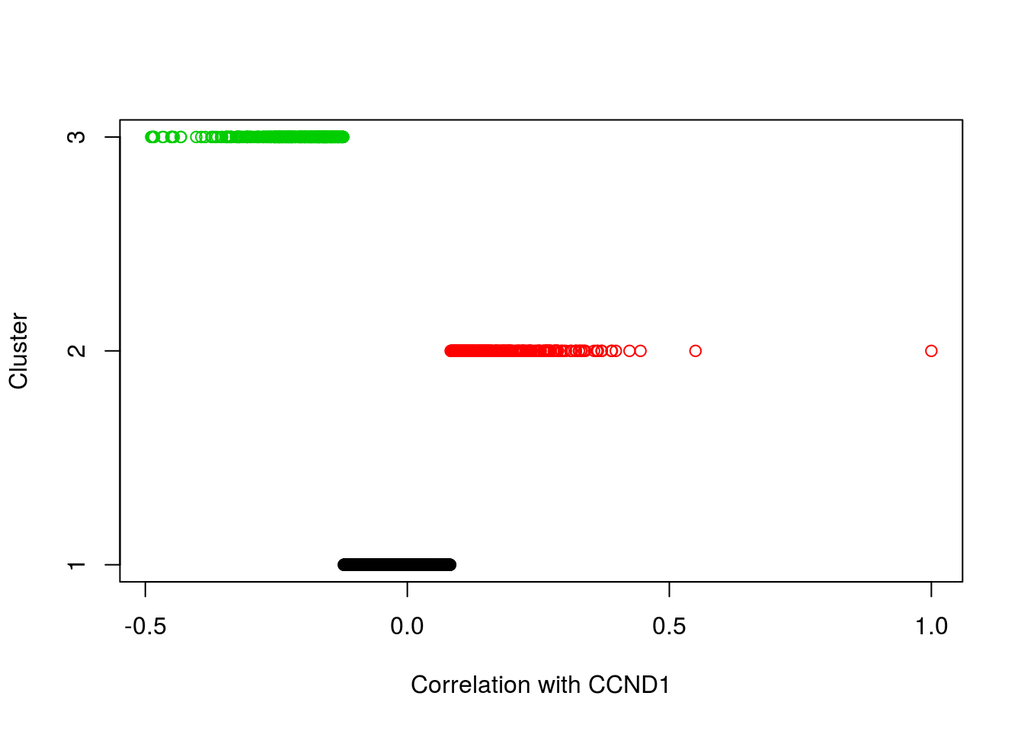

```r
plot(aux, col=aux[,-1], yaxt='n', ylab='Cluster', xlab='Correlation with CCND1')
axis(side=2, at=c(1,2,3))
```

```r
common_norm_names <- rownames(common_gse_norm)
common_gse_norm_cor <- as.matrix(cbind(common_gse_norm, aux))
#common_gse_norm_fact <-
#head(cbind(as.matrix(common_gse_norm, aux)))
head(common_gse_norm_cor)
```

```
##              GSM536113  GSM536114  GSM536115  GSM536116  GSM536117
## 209480_at    0.9173780  0.9507022  0.3588124  0.5805468  0.9248119
## 213831_at    0.8100521  1.0373505  0.6419594  0.7910033  0.9562644
## 209728_at   -1.3381896 -0.6956372  0.8110106 -1.1236592  0.9624286
## 213831_at    0.8100521  1.0373505  0.6419594  0.7910033  0.9562644
## 209728_at   -1.3381896 -0.6956372  0.8110106 -1.1236592  0.9624286
## 216365_x_at -0.3112425  1.6613059 -1.3721458  1.6598426 -0.2559292
##             GSM536118  GSM536119  GSM536120  GSM536121 GSM536122
## 209480_at   -1.306374  0.8996905  1.0306804 -1.6078307 -1.542977
## 213831_at   -1.267038  0.9647592  0.9544625 -1.4129929 -1.666805
## 209728_at    1.103458 -0.9273093 -0.6164220  0.7585467 -1.539474
## 213831_at   -1.267038  0.9647592  0.9544625 -1.4129929 -1.666805
## 209728_at    1.103458 -0.9273093 -0.6164220  0.7585467 -1.539474
## 216365_x_at -1.015097  1.4330288 -0.7909171  1.7213018  1.297233
##              GSM536123  GSM536124  GSM536125  GSM536126  GSM536127
## 209480_at   -0.8734156  0.9381416 -0.8582915 -0.8582915 -0.6603968
## 213831_at   -1.9422403  0.6962742 -1.3069375 -1.5723334 -0.7195141
## 209728_at    0.9413911  0.8333467  1.1424160 -0.5849956  0.5946621
## 213831_at   -1.9422403  0.6962742 -1.3069375 -1.5723334 -0.7195141
## 209728_at    0.9413911  0.8333467  1.1424160 -0.5849956  0.5946621
## 216365_x_at  1.1254400 -0.7022402 -0.3984561 -1.3850229  1.3589851
##              GSM536128  GSM536129  GSM536130 GSM536131  GSM536132
## 209480_at   -0.9882561  0.8745691  1.1211686 -1.530416  0.8717494
## 213831_at   -1.2258514  0.7137785  1.0412117 -1.070630  0.7523909
## 209728_at   -1.3213077  0.7811426 -0.7514774  1.156701 -0.9215954
## 213831_at   -1.2258514  0.7137785  1.0412117 -1.070630  0.7523909
## 209728_at   -1.3213077  0.7811426 -0.7514774  1.156701 -0.9215954
## 216365_x_at -0.2055912 -1.1889387 -0.7291652  1.710766 -0.3390455
##             GSM536133  GSM536134  GSM536135  GSM536136  GSM536137
## 209480_at   0.6584742  0.9299387  0.6907731  1.0957909 -1.3414931
## 213831_at   0.7637172  1.0077476  0.7580541  0.9150779 -1.1717941
## 209728_at   0.8310092 -1.2818299  0.7793245 -0.7787483  1.0608633
## 213831_at   0.7637172  1.0077476  0.7580541  0.9150779 -1.1717941
## 209728_at   0.8310092 -1.2818299  0.7793245 -0.7787483  1.0608633
## 216365_x_at 1.4508812 -0.5076193 -1.4467748 -0.6363911 -0.4312343
##               GSM536138 GSM536139 GSM536140  GSM536141  GSM536142
## 209480_at   -1.71267388 -1.618084 0.9812067  0.5941328 -0.7314031
## 213831_at   -0.91566509 -1.219416 0.9305228  0.6432465 -0.8670135
## 209728_at    0.89957584  0.895680 0.9948938 -1.6381686  0.7037454
## 213831_at   -0.91566509 -1.219416 0.9305228  0.6432465 -0.8670135
```

[output cut: 57 more lines]

```
## 216365_x_at 0.7838784  1.048604 -0.8148978 -0.4028434 -1.0324348 0.1062205
##             GSM634853 GSM634854  GSM634855  GSM634856  GSM634857
## 209480_at   0.9696799 0.9494854 -0.9341120 -0.9306518 -1.0152476
## 213831_at   0.7912702 1.0698718 -1.4524223 -0.7569706 -1.0519079
## 209728_at   1.1908927 0.8698203 -1.2843383 -0.9613500 -1.1384583
## 213831_at   0.7912702 1.0698718 -1.4524223 -0.7569706 -1.0519079
## 209728_at   1.1908927 0.8698203 -1.2843383 -0.9613500 -1.1384583
## 216365_x_at 0.5369526 2.3241595 -0.6320228 -0.8417359 -0.4847819
##               cor_ccnd1 cor_factor
## 209480_at   -0.30565746          3
## 213831_at   -0.30482277          3
## 209728_at   -0.13838584          3
## 213831_at   -0.30482277          3
## 209728_at   -0.13838584          3
## 216365_x_at  0.01479666          1
```

Now that we have classified our genes in terms of correlation with CCND1, we can use only the ones classified with higher correlation.

```r
#common_gse_norm_cor[common_gse_norm_cor[, "cor_factor"]==3,]
common_gse_norm_cor["208712_at", "cor_factor"]
```

```
## [1] 2
```

```r
cor_factor$centers
```

```
##          [,1]
## 1 -0.02009226
## 2  0.18455815
## 3 -0.22270509
```

We can get the group 2 with positive correlation and group 3 with negative correlation. The group 1 has the smaller correlation.

```r
commons_norm_cor_1 <- common_gse_norm_cor[common_gse_norm_cor[, "cor_factor"]==1,]
commons_norm_cor_2 <- common_gse_norm_cor[common_gse_norm_cor[, "cor_factor"]==2,]
commons_norm_cor_3 <- common_gse_norm_cor[common_gse_norm_cor[, "cor_factor"]==3,]
```

```r
nrow(commons_norm_cor_2)
```

```
## [1] 316
```

## 1.7 Feature Selection

### 1.7.1 Unsupervised Feature Selection

We can now perform a feature selection on the correlated genes. For that, we are going to start with an unsupervised random forest.

```r
set.seed(42)

rf_cor_1 <- randomForest(t(commons_norm_cor_1))
rf_cor_2 <- randomForest(t(commons_norm_cor_2))#, importance=TRUE, proximity = TRUE)
rf_cor_3 <- randomForest(t(commons_norm_cor_3))
```

```r
rf_cor_1_vars <- importance(rf_cor_1)
rf_cor_2_vars <- importance(rf_cor_2)
rf_cor_3_vars <- importance(rf_cor_3)
#head(urf_vars)
#rownames(urf_vars)[order(-urf_vars)]
#rownames(drf_vars)[order(-drf_vars)]
```

```r
summary(rf_cor_2)
```

```
##                 Length Class  Mode
## call               2   -none- call
## type               1   -none- character
## predicted          0   -none- NULL
## err.rate           0   -none- NULL
## confusion          0   -none- NULL
## votes            156   matrix numeric
## oob.times         78   -none- numeric
## classes            2   -none- character
## importance       316   -none- numeric
## importanceSD       0   -none- NULL
## localImportance    0   -none- NULL
## proximity       6084   -none- numeric
## ntree              1   -none- numeric
## mtry               1   -none- numeric
## forest             0   -none- NULL
## y                  0   -none- NULL
## test               0   -none- NULL
## inbag              0   -none- NULL
```

```r
# Let's find in which position do we have the cyclin d1
match(c("208712_at"), rownames(as.matrix(rf_cor_2_vars[order(-rf_cor_2_vars),])))
```

```
## [1] 202
```

```r
# get the top 20, and the top 205 for the second cluster
rf_cor_1_top <- as.matrix(head(rf_cor_1_vars[order(-rf_cor_1_vars),], 20))
rf_cor_2_top <- as.matrix(head(rf_cor_2_vars[order(-rf_cor_2_vars),], 205))
rf_cor_3_top <- as.matrix(head(rf_cor_3_vars[order(-rf_cor_3_vars),], 20))

#drf_top <- as.matrix(head(drf_vars[order(-drf_vars),], 20))
head(rf_cor_1_top)
```

```
##                  [,1]
## 224407_s_at 0.2757649
## 215396_at   0.2577104
## 237215_s_at 0.2479126
## 206085_s_at 0.2450506
## 221628_s_at 0.2424283
## 231588_at   0.2384551
```

```r
head(rf_cor_2_top)
```

```
##                  [,1]
## 212009_s_at 0.4281271
## 213548_s_at 0.4102113
## 219456_s_at 0.3979288
## 212575_at   0.3946288
## 1558654_at  0.3855344
## 233827_s_at 0.3843942
```

```r
head(rf_cor_3_top)
```

```
##                   [,1]
## 220177_s_at  0.3449758
## 220177_s_at  0.3231287
## 1557217_a_at 0.3142037
## 1553140_at   0.3126743
## 240990_at    0.3068669
## 220177_s_at  0.3028953
```

```r
#rownames(urf_vars)
#rownames(urf_vars[order(-urf_vars),])
```

```r
#class(urf_top)
#rownames(urf_top)
top_cor_1_genes <- common_gse_norm[rownames(rf_cor_1_top),]
top_cor_2_genes <- common_gse_norm[rownames(rf_cor_2_top),]
top_cor_3_genes <- common_gse_norm[rownames(rf_cor_3_top),]
#common_gse
#top_down_genes
```

And finally, we need to save the files that will be used for running GSEA.

```r
no_dupl_cor_1_genes <- top_cor_1_genes[!duplicated(rownames(top_cor_1_genes)),]
no_dupl_cor_2_genes <- top_cor_2_genes[!duplicated(rownames(top_cor_2_genes)),]
no_dupl_cor_3_genes <- top_cor_3_genes[!duplicated(rownames(top_cor_3_genes)),]

c_gse_expset_cor_1 <-new("ExpressionSet", exprs=as.matrix(no_dupl_cor_1_genes))
c_gse_expset_cor_2 <-new("ExpressionSet", exprs=as.matrix(no_dupl_cor_2_genes))
c_gse_expset_cor_3 <-new("ExpressionSet", exprs=as.matrix(no_dupl_cor_3_genes))

output.gct(c_gse_expset_cor_1, filename = "data/c_gse_expset_cor_1")
output.gct(c_gse_expset_cor_2, filename = "data/c_gse_expset_cor_2")
output.gct(c_gse_expset_cor_3, filename = "data/c_gse_expset_cor_3")
```

```r
#match(c("208712_at"), rownames(rf_cor_2_vars))
#rf_cor_2_vars[70,]
#rf_cor_2_vars["208712_at",]
# Let's find in which position do we have the cyclin d1
match(c("208712_at"), rownames(as.matrix(rf_cor_2_vars[order(-rf_cor_2_vars),])))
```

```
## [1] 202
```

```r
#length(rf_cor_2_vars)
```

## 1.8 Extra: Supervised Feature Selection

### 1.8.1 Random Forest

Let’s create a new column for our common genes dataset containing the information about the procedence of the sample. In that way we can use it as a class and use supervised methods for classification.

```r
#class(common_gse_norm)
extended_common_cor <- t(common_gse_norm)
tail(data.frame(extended_common_cor))
```

```
##           X209480_at X213831_at X209728_at X213831_at.1 X209728_at.1
## GSM634852  1.0902166  0.5410405  0.8254537    0.5410405    0.8254537
## GSM634853  0.9696799  0.7912702  1.1908927    0.7912702    1.1908927
## GSM634854  0.9494854  1.0698718  0.8698203    1.0698718    0.8698203
## GSM634855 -0.9341120 -1.4524223 -1.2843383   -1.4524223   -1.2843383
## GSM634856 -0.9306518 -0.7569706 -0.9613500   -0.7569706   -0.9613500
## GSM634857 -1.0152476 -1.0519079 -1.1384583   -1.0519079   -1.1384583
##           X216365_x_at X201909_at X213831_at.2 X209480_at.1 X238900_at
## GSM634852    0.1062205 -0.5032643    0.5410405    1.0902166 -0.9106095
## GSM634853    0.5369526 -0.1523649    0.7912702    0.9696799 -1.0209717
## GSM634854    2.3241595 -1.0883628    1.0698718    0.9494854 -0.9433231
## GSM634855   -0.6320228  0.8110736   -1.4524223   -0.9341120  0.7526225
## GSM634856   -0.8417359  0.7633188   -0.7569706   -0.9306518  0.8350152
## GSM634857   -0.4847819 -0.2345472   -1.0519079   -1.0152476  0.8448247
##           X206700_s_at X203819_s_at X204409_s_at X204409_s_at.1 X235557_at
## GSM634852  -0.22402693    0.7750861    0.6215146      0.6215146  1.2228914
## GSM634853  -0.05686479    0.9125867    0.5647707      0.5647707  0.4584991
## GSM634854  -0.22624543    1.0288707    1.2586743      1.2586743  1.6494057
## GSM634855  -1.33572174   -1.1809467   -0.5957449     -0.5957449 -0.4036126
## GSM634856  -0.64690677   -0.8522477   -0.3445611     -0.3445611 -0.3934027
## GSM634857   1.17832818   -0.5061112   -0.3981557     -0.3981557 -0.4697185
##           X223646_s_at X223646_s_at.1 X223646_s_at.2 X221690_s_at
## GSM634852    0.7444531      0.7444531      0.7444531  -0.00241455
## GSM634853    1.0809993      1.0809993      1.0809993   0.20537472
## GSM634854    1.3379158      1.3379158      1.3379158   0.52822972
## GSM634855   -0.9809698     -0.9809698     -0.9809698  -0.47296241
## GSM634856   -0.1582545     -0.1582545     -0.1582545  -0.90934678
## GSM634857    0.2810375      0.2810375      0.2810375  -0.49818542
##           X216365_x_at.1 X224499_s_at X223646_s_at.3 X203819_s_at.1
## GSM634852      0.1062205   -0.6492123      0.7444531      0.7750861
## GSM634853      0.5369526   -0.5233472      1.0809993      0.9125867
## GSM634854      2.3241595   -0.2255326      1.3379158      1.0288707
## GSM634855     -0.6320228    1.1254457     -0.9809698     -1.1809467
## GSM634856     -0.8417359    0.6373849     -0.1582545     -0.8522477
## GSM634857     -0.4847819    2.4634209      0.2810375     -0.5061112
##           X205780_at X228058_at X224499_s_at.1 X219355_at X218717_s_at
## GSM634852  0.6328539  0.7264674     -0.6492123  0.6471945    0.7770551
## GSM634853 -0.2036243  0.1291827     -0.5233472  0.9229511    0.4846444
## GSM634854  1.0162987  0.6175449     -0.2255326  1.2571586    0.3452847
## GSM634855 -0.7933353 -0.9070787      1.1254457 -1.0252666   -0.7367499
```

[output cut: 1821 more lines]

```
## GSM634857 -1.8270142  0.1063665 -0.03613734   -0.8561173   -1.0152476
##           X209834_at X1555748_x_at X1553673_at X200841_s_at X1562650_at
## GSM634852 -1.0395979    -1.0097021   0.8175316    0.5827713 -0.06395439
## GSM634853 -0.8435623    -1.4949445   1.3404481    1.2391687 -0.55343378
## GSM634854 -0.8563404    -1.2405148   0.9901777   -1.1302097 -0.06846534
## GSM634855  0.4794379     1.1029888  -1.1649944    0.2970062 -1.50508835
## GSM634856  1.4582987     0.8395103  -1.1620522    0.4408208 -0.43422935
## GSM634857  1.3960080    -0.1888273   0.3015583   -2.3110950  0.08496519
##           X219181_at
## GSM634852  0.5420135
## GSM634853  0.4562379
## GSM634854  0.6847780
## GSM634855 -1.6014485
## GSM634856 -0.4674167
## GSM634857 -0.7417314
```

```r
#extended_common_cor
```

```r
#cbind(extended_common_cor, cl)
#c1_ext <- rep(0, ncol(common_gse_21_norm))
#c2_ext <- rep(1, ncol(common_gse_25_norm))
#cl_ext <- c(c1_ext, c2_ext)
#length(cl_ext)
```

```r
# Not really needed
#extended_common_cor <- cbind(extended_common_cor, cl)
#tail(colnames(extended_common_cor))
#class(extended_common_cor)
```

We need to remove duplicates before running randomForest.

```r
#ext_no_dupl_common_cor <- data.frame(extended_common_cor[,!duplicated(colnames(extended_common_cor))])
ext_no_dupl_common_cor <- extended_common_cor[,!duplicated(colnames(extended_common_cor))]

#ext_no_dupl_common_cor$cl <- factor(ext_no_dupl_common_cor$cl)
#levels(ext_no_dupl_common_cor$cl) <- c("MCL", "DDR")
#head(ext_no_dupl_common_cor$cl)
#tail(ext_no_dupl_common_cor$cl)

#aux$cor_factor <- factor(aux$cor_factor)
#levels(aux$cor_factor) <- c("Low","Medium","High")
```

Now that we have our data set, let’s run a randomForest

```r
set.seed(42)
class(ext_no_dupl_common_cor)
```

```
## [1] "matrix"
```

```r
#ncol(exprs(common_gse_21_norm))
#ncol(exprs(common_gse_25_norm))
#c2 <- rep(1, ncol(exprs(common_gse_25)))
c1 <- rep(0, ncol(exprs(common_gse_21_norm)))
c2 <- rep(1, ncol(exprs(common_gse_25_norm)))
cl <- c(c1, c2)
#cl

# Create labels for classification
ext_cl_fact <- factor(cl)
levels(ext_cl_fact) <- c("MCL", "DDR")
#ext_rf <- randomForest(cl ~ ., data=data.frame(ext_no_dupl_common_cor))
#ext_rf <- randomForest(y=ext_no_dupl_common_cor$cl, x=ext_no_dupl_common_cor)

# Create the model
ext_rf <- randomForest(y=ext_cl_fact, x=ext_no_dupl_common_cor)
ext_rf_vars <- importance(ext_rf)

# Find the accuracy of the model
#ext_rf_cv <- rf.crossV

# get the top 20
ext_rf_top_20 <- as.matrix(head(ext_rf_vars[order(-ext_rf_vars),], 20))
#ext_rf_top_20

match(c("208712_at"), rownames(as.matrix(ext_rf_vars[order(-ext_rf_vars),])))
```

```
## [1] 24
```

```r
#ext_rf_top_200 <- as.matrix(head(ext_rf_vars[order(-ext_rf_vars),], 200))
#ext_rf_top_300 <- as.matrix(head(ext_rf_vars[order(-ext_rf_vars),], 310))
ext_rf_top_100 <- as.matrix(head(ext_rf_vars[order(-ext_rf_vars),], 100))

#ext_rf_top_200
#match(c("208712_at"), rownames(ext_rf_top_300))
#ext_top_200 <- common_gse_norm[rownames(ext_rf_top_200),]
#ext_top_300 <- common_gse_norm[rownames(ext_rf_top_300),]
ext_top_100 <- common_gse_norm[rownames(ext_rf_top_100),]

#no_dupl_ext_top_300 <- ext_top_300[!duplicated(rownames(ext_top_300)),]
no_dupl_ext_top_100 <- ext_top_100[!duplicated(rownames(ext_top_100)),]
#match(c("208712_at"), rownames(no_dupl_ext_top_300))
match(c("208712_at"), rownames(no_dupl_ext_top_100))
```

```
## [1] 24
```

```r
#ext_c_gse_expset_cor <-new("ExpressionSet", exprs=as.matrix(no_dupl_ext_top_300))
ext_c_gse_expset_cor <-new("ExpressionSet", exprs=as.matrix(no_dupl_ext_top_100))

#output.gct(ext_c_gse_expset_cor, filename = "data/no_dupl_ext_top_200")
##output.gct(ext_c_gse_expset_cor, filename = "data/top_310_rf")
output.gct(ext_c_gse_expset_cor, filename = "data/top_100_srf")

#as.matrix(head(ext_rf_vars[order(-ext_rf_vars),], 20))

#importance(ext_rf)
#rf_cor_1_vars
#ext_rf[order(-ext_rf),]
```

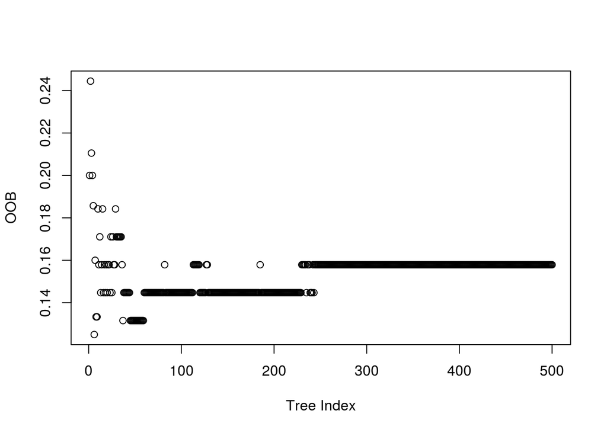

```r
#print(ext_rf$err.rate)
#print(ext_rf$err.rate)
plot(ext_rf$err.rate[,1], ylab="OOB", xlab="Tree Index")
```

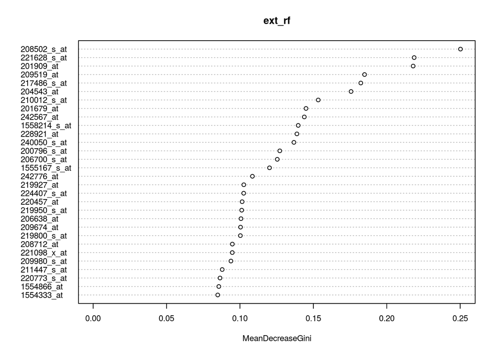

```r
varImpPlot(ext_rf, cex=0.70)
```

```r
#impToPlot <- importance(ext_rf)#, scale = FALSE)
#dotchart(head(sort(impToPlot[,1]),25), cex=0.8, xlim=c(0,0.5), xlab="MeanDecreaseGini")
```

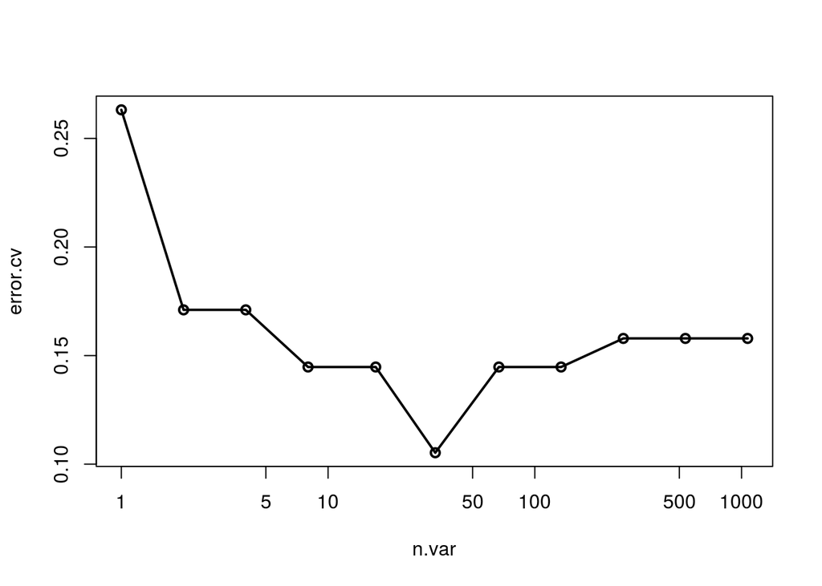

```r
#print(ext_rf)
#MDSplot(ext_rf, ext_cl_fact)


# Let's use a cross validation version
ext_rfcv_result <- rfcv(ext_no_dupl_common_cor, ext_cl_fact, cv.fold=10)
with(ext_rfcv_result, plot(n.var, error.cv, log="x", type="o", lwd=2))
```

```r
ext_rfcv_result$predicted
```

```
## $`1070`
##  [1] MCL MCL MCL MCL MCL MCL MCL MCL MCL MCL MCL MCL MCL MCL MCL MCL MCL
## [18] MCL MCL MCL MCL MCL MCL MCL MCL MCL MCL MCL MCL MCL MCL MCL MCL MCL
## [35] MCL MCL MCL MCL MCL MCL MCL MCL MCL MCL MCL MCL MCL MCL MCL MCL MCL
## [52] MCL MCL MCL MCL MCL MCL MCL MCL MCL MCL MCL MCL MCL MCL MCL MCL MCL
## [69] MCL MCL MCL MCL MCL MCL MCL MCL
## Levels: MCL DDR
##
## $`535`
##  [1] MCL MCL MCL MCL MCL MCL MCL MCL MCL MCL MCL MCL MCL MCL MCL MCL MCL
## [18] MCL MCL MCL MCL MCL MCL MCL MCL MCL MCL MCL MCL MCL MCL MCL MCL MCL
## [35] MCL MCL MCL MCL MCL MCL MCL MCL MCL MCL MCL MCL MCL MCL MCL MCL MCL
## [52] MCL MCL MCL MCL MCL MCL MCL MCL MCL MCL MCL MCL MCL MCL MCL MCL MCL
## [69] MCL MCL MCL MCL MCL MCL MCL MCL
## Levels: MCL DDR
##
## $`268`
##  [1] MCL MCL MCL MCL MCL MCL MCL MCL MCL MCL MCL MCL MCL MCL MCL MCL MCL
## [18] MCL MCL MCL MCL MCL MCL MCL MCL MCL MCL MCL MCL MCL MCL MCL MCL MCL
## [35] MCL MCL MCL MCL MCL MCL MCL MCL MCL MCL MCL MCL MCL MCL MCL MCL MCL
## [52] MCL MCL MCL MCL MCL MCL MCL MCL MCL MCL MCL MCL MCL MCL MCL MCL MCL
## [69] MCL MCL MCL MCL MCL MCL MCL MCL
## Levels: MCL DDR
##
## $`134`
##  [1] MCL MCL MCL MCL MCL MCL MCL MCL MCL MCL MCL MCL MCL MCL MCL MCL MCL
## [18] MCL MCL MCL MCL MCL MCL MCL MCL MCL MCL MCL MCL MCL MCL MCL MCL MCL
## [35] MCL MCL MCL MCL MCL MCL MCL MCL MCL MCL MCL MCL MCL MCL MCL MCL MCL
## [52] MCL MCL MCL MCL MCL MCL MCL MCL MCL MCL MCL MCL MCL MCL MCL DDR MCL
## [69] MCL MCL MCL MCL MCL MCL MCL MCL
## Levels: MCL DDR
##
## $`67`
##  [1] MCL MCL MCL MCL MCL MCL MCL MCL MCL MCL MCL MCL MCL MCL MCL MCL MCL
## [18] MCL MCL MCL MCL MCL MCL MCL MCL MCL MCL MCL MCL MCL MCL MCL MCL MCL
## [35] MCL MCL MCL MCL MCL MCL MCL MCL MCL MCL MCL MCL MCL MCL MCL MCL MCL
## [52] MCL MCL MCL MCL MCL MCL MCL MCL MCL MCL MCL MCL MCL MCL MCL MCL MCL
## [69] MCL MCL MCL MCL MCL DDR MCL MCL
## Levels: MCL DDR
##
```

[output cut: 32 more lines]

```
## $`2`
##  [1] MCL MCL MCL MCL MCL MCL MCL MCL MCL MCL MCL MCL MCL MCL MCL MCL MCL
## [18] DDR MCL MCL MCL MCL MCL MCL MCL MCL MCL MCL MCL MCL MCL MCL MCL MCL
## [35] MCL MCL MCL MCL MCL MCL MCL MCL MCL MCL MCL MCL MCL MCL MCL MCL MCL
## [52] MCL MCL MCL MCL MCL MCL MCL MCL MCL DDR MCL MCL DDR DDR MCL MCL MCL
## [69] MCL DDR MCL MCL MCL MCL MCL MCL
## Levels: MCL DDR
##
## $`1`
##  [1] MCL MCL MCL MCL MCL MCL DDR MCL MCL MCL MCL MCL MCL MCL MCL MCL MCL
## [18] MCL MCL MCL MCL MCL MCL MCL MCL MCL MCL MCL DDR MCL MCL DDR DDR MCL
## [35] MCL MCL MCL MCL MCL MCL MCL DDR MCL MCL MCL MCL DDR MCL MCL MCL MCL
## [52] DDR MCL MCL MCL MCL DDR MCL MCL DDR DDR DDR MCL MCL DDR MCL MCL MCL
## [69] MCL MCL DDR MCL DDR MCL MCL MCL
## Levels: MCL DDR
```

```r
#importance(ext_rfcv_result)
```

### 1.8.2 Boruta

```r
library(Boruta)
set.seed(42)
# boruta.bank_train <- Boruta(y~., data = amelia_bank$imputations[[1]], doTrace = 2)
ext_boruta <- Boruta(y=ext_cl_fact, x=ext_no_dupl_common_cor, doTrace = 2)
```

```
##  1. run of importance source...
```

```
##  2. run of importance source...
```

```
##  3. run of importance source...
```

```
##  4. run of importance source...
```

```
##  5. run of importance source...
```

```
##  6. run of importance source...
```

```
##  7. run of importance source...
```

```
##  8. run of importance source...
```

```
##  9. run of importance source...
```

```
##  10. run of importance source...
```

```
##  11. run of importance source...
```

```
##  12. run of importance source...
```

```
##  13. run of importance source...
```

```
##  14. run of importance source...
```

```
##  15. run of importance source...
```

```
##  16. run of importance source...
```

```
##  17. run of importance source...
```

```
## After 17 iterations, +8.9 secs:
```

```
##  rejected 1063 attributes: AFFX.HUMISGF3A.M97935_5_at, X1552276_a_at, X1552365_at, X1552372_at, X1552379_at and 1058 more;
```

```
##  still have 7 attributes left.
```

```
##  18. run of importance source...
```

```
##  19. run of importance source...
```

```
##  20. run of importance source...
```

```
##  21. run of importance source...
```

```
##  22. run of importance source...
```

```
##  23. run of importance source...
```

```
##  24. run of importance source...
```

```
##  25. run of importance source...
```

```
##  26. run of importance source...
```

```
##  27. run of importance source...
```

```
##  28. run of importance source...
```

```
##  29. run of importance source...
```

```
##  30. run of importance source...
```

```
##  31. run of importance source...
```

```
##  32. run of importance source...
```

```
##  33. run of importance source...
```

```
##  34. run of importance source...
```

```
##  35. run of importance source...
```

```
##  36. run of importance source...
```

```
##  37. run of importance source...
```

```
##  38. run of importance source...
```

```
##  39. run of importance source...
```

```
##  40. run of importance source...
```

```
##  41. run of importance source...
```

```
##  42. run of importance source...
```

```
##  43. run of importance source...
```

```
##  44. run of importance source...
```

```
##  45. run of importance source...
```

```
##  46. run of importance source...
```

```
##  47. run of importance source...
```

```
##  48. run of importance source...
```

```
##  49. run of importance source...
```

```
##  50. run of importance source...
```

```
##  51. run of importance source...
```

```
## After 51 iterations, +9.4 secs:
```

```
##  confirmed 1 attribute: X201909_at;
```

```
##  still have 6 attributes left.
```

```
##  52. run of importance source...
```

```
##  53. run of importance source...
```

```
##  54. run of importance source...
```

```
##  55. run of importance source...
```

```
##  56. run of importance source...
```

```
##  57. run of importance source...
```

```
##  58. run of importance source...
```

```
##  59. run of importance source...
```

```
##  60. run of importance source...
```

```
##  61. run of importance source...
```

```
##  62. run of importance source...
```

```
## After 62 iterations, +9.6 secs:
```

```
##  confirmed 1 attribute: X208502_s_at;
```

```
##  still have 5 attributes left.
```

```
##  63. run of importance source...
```

```
##  64. run of importance source...
```

```
##  65. run of importance source...
```

```
##  66. run of importance source...
```

```
##  67. run of importance source...
```

```
##  68. run of importance source...
```

```
## After 68 iterations, +9.6 secs:
```

```
##  confirmed 2 attributes: X201679_at, X209674_at;
```

```
##  still have 3 attributes left.
```

```
##  69. run of importance source...
```

```
##  70. run of importance source...
```

```
##  71. run of importance source...
```

```
## After 71 iterations, +9.7 secs:
```

```
##  confirmed 1 attribute: X1554866_at;
```

```
##  still have 2 attributes left.
```

```
##  72. run of importance source...
```

```
##  73. run of importance source...
```

```
##  74. run of importance source...
```

```
##  75. run of importance source...
```

```
##  76. run of importance source...
```

```
## After 76 iterations, +9.8 secs:
```

```
##  confirmed 1 attribute: X206638_at;
```

```
##  still have 1 attribute left.
```

```
##  77. run of importance source...
```

```
##  78. run of importance source...
```

```
##  79. run of importance source...
```

```
##  80. run of importance source...
```

```
##  81. run of importance source...
```

```
## After 81 iterations, +9.8 secs:
```

```
##  confirmed 1 attribute: X1558214_s_at;
```

```
##  no more attributes left.
```

```r
print(ext_boruta)
```

```
## Boruta performed 81 iterations in 9.829534 secs.
##  7 attributes confirmed important: X1554866_at, X1558214_s_at,
## X201679_at, X201909_at, X206638_at and 2 more;
##  1063 attributes confirmed unimportant:
## AFFX.HUMISGF3A.M97935_5_at, X1552276_a_at, X1552365_at,
## X1552372_at, X1552379_at and 1058 more;
```

```r
#importance(ext_boruta)
getSelectedAttributes(ext_boruta, withTentative = TRUE)
```

```
## [1] "X201909_at"    "X208502_s_at"  "X1558214_s_at" "X209674_at"
## [5] "X201679_at"    "X206638_at"    "X1554866_at"
```

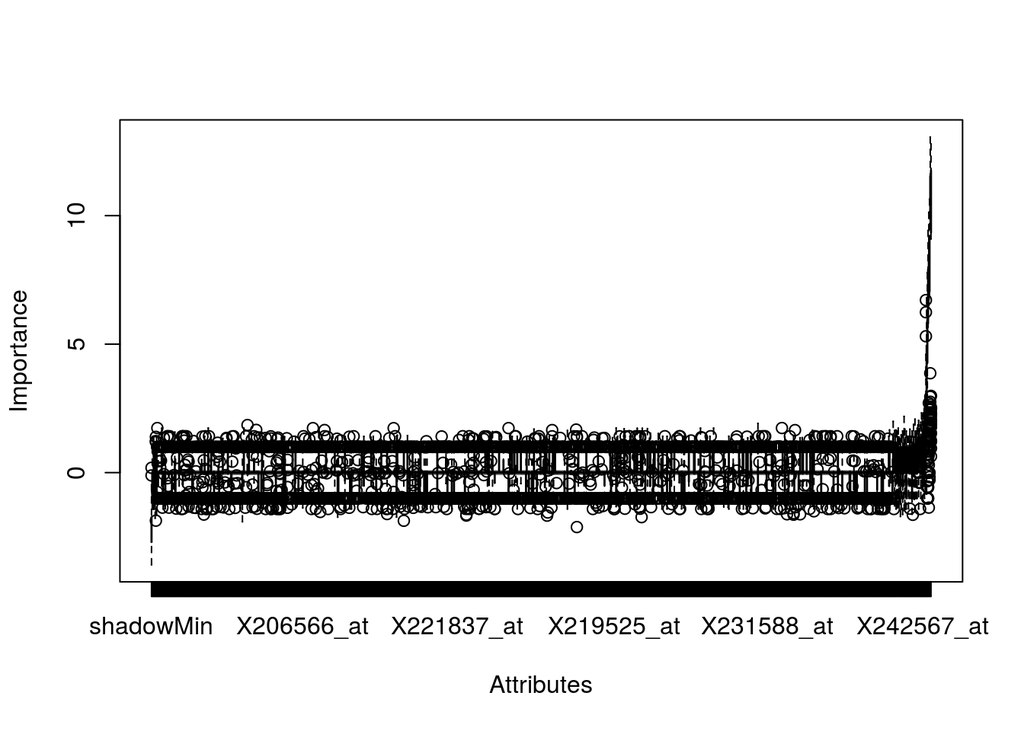

```r
plot(ext_boruta)
```

### 1.8.3 Regression